# Depth diversity gradients of macrophytes: shape, drivers and recent shifts

Supporting information I

21 December 2020

# 1 Depth diversity gradients (DDG) of macrophytes: shape

## 1.1 DDG of all field campaigns

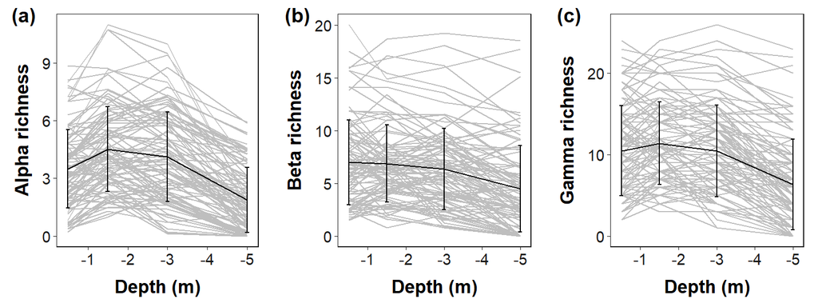

```r
A1<-ggplot(data=Makroph_Lake_DepthS)+
  geom_line(aes(x=Tiefe, y=ALPHA, group=interaction(Lake, YEAR)),col="grey")+
  scale_x_reverse()+
  geom_line(data=Makroph_Depth,aes(x=(Tiefe), y=mAlpha))+
  geom_errorbar(data=Makroph_Depth,aes(x=(Tiefe),ymin=mAlpha-sdAlpha, ymax=mAlpha+sdAlpha), width=.1)+
  ylab("Alpha richness")+xlab(("Depth (m)"))
B1<-ggplot(data=Makroph_Lake_DepthS)+
  geom_line(aes(x=Tiefe, y=BETA, group=interaction(Lake, YEAR)),col="grey")+ scale_x_reverse()+
  geom_line(data=Makroph_Depth,aes(x=(Tiefe), y=mBeta))+
  geom_errorbar(data=Makroph_Depth,aes(x=(Tiefe),ymin=mBeta-sdBeta, ymax=mBeta+sdBeta), width=.1)+
  ylab("Beta richness")+xlab(("Depth (m)"))
C1<-ggplot(data=Makroph_Lake_DepthS)+
  geom_line(aes(x=Tiefe, y=GAMMA, group=interaction(Lake, YEAR)),col="grey")+ scale_x_reverse()+
  geom_line(data=Makroph_Depth,aes(x=(Tiefe), y=mGamma))+
  geom_errorbar(data=Makroph_Depth,aes(x=(Tiefe),ymin=mGamma-sdGamma, ymax=mGamma+sdGamma), width=.1)+
  ylab("Gamma richness")+xlab(("Depth (m)"))
ggarrange(A1,B1,C1,ncol=3,nrow=1,labels=c("(a)","(b)","(c)"))
```

Figure 1: Depth diversity gradients of macrophytes for alpha (a), beta (b) and gamma richness (c) with mean as black line and sd as black bars. Each single grey line is one field campaign (lake*year).

## 1.2 DDG per lake

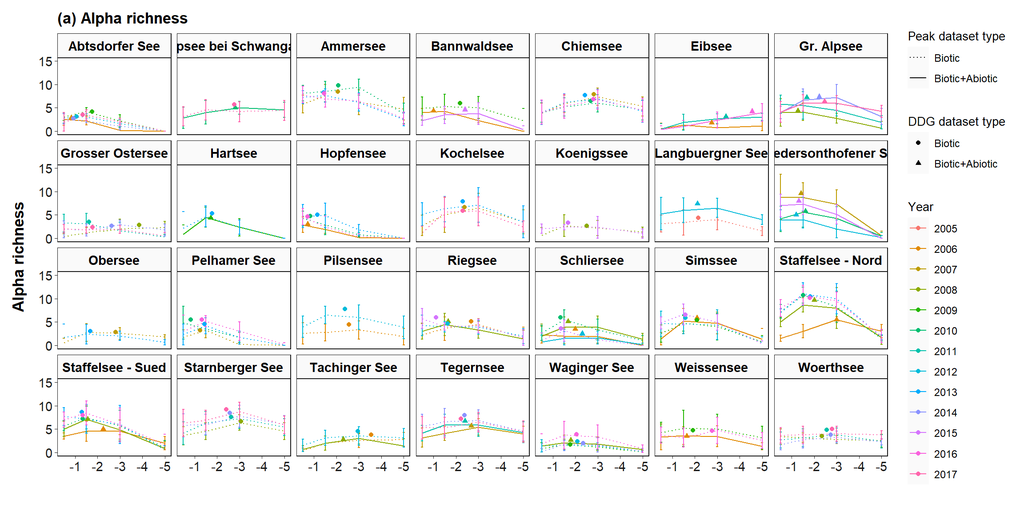

```r
### ALPHA & Peak Plot
ggplot(data=Makroph_Lake_DepthS, aes(x=(Tiefe), y=ALPHA, col=factor(YEAR),
                                     group=interaction(Lake,YEAR)))+
  geom_line(aes(linetype=datasettotsimpl))+
  scale_linetype_manual(values=c("dotted", "solid"))+
  facet_wrap(~ Lake, ncol=7)+
  ylab("Alpha richness")+ xlab("")+labs(fill = "Pattern type")+ylim(0,15)+
  geom_errorbar(data=Makroph_Lake_DepthS,aes(ymin=ALPHA-ALPHAsd, ymax=ALPHA+ALPHAsd), width=.1)+
  geom_point(data=PEAK, aes(x=(AlphaPeakDepth), y=AlphaPeakRichness, shape=datasettotsimpl))+
  scale_x_reverse()+
  labs(linetype="Peak dataset type",shape="DDG dataset type", colour="Year")+
  ggtitle("(a) Alpha richness")
```

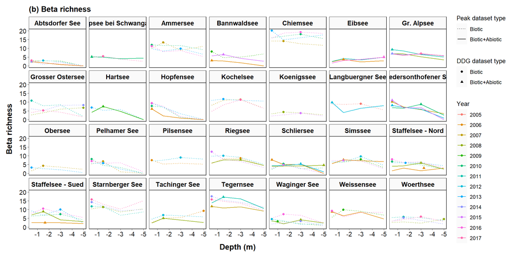

```r
### BETA & Peak Plot
ggplot(Makroph_Lake_DepthS, aes(x=Tiefe, y=BETA, group=interaction(Lake,YEAR), col=factor(YEAR),
                                linetype=datasettotsimpl))+
  geom_line()+facet_wrap(~ Lake, ncol=7)+
  scale_linetype_manual(values=c("dotted", "solid"))+
  ylab("Beta richness")+ xlab("Depth (m)")+labs(fill = "Pattern type")+
  geom_point(data=PEAK, aes(x=BetaPeakDepth, y=BetaPeakRichness, shape=datasettotsimpl))+
  scale_x_reverse()+
  labs(linetype="Peak dataset type",shape="DDG dataset type", colour="Year")+
  ggtitle("(b) Beta richness")
```

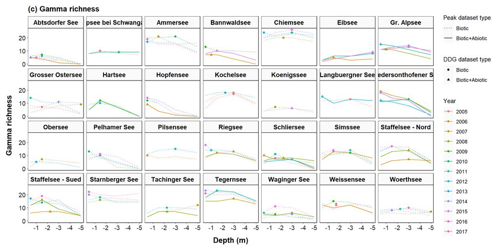

```r
### GAMMA & Peak Plot
ggplot(Makroph_Lake_DepthS, aes(x=Tiefe, y=GAMMA, group=interaction(Lake,YEAR), col=factor(YEAR),
                                linetype=datasettotsimpl))+
  geom_line()+facet_wrap(~ Lake, ncol=7)+
  scale_linetype_manual(values=c("dotted", "solid"))+
  ylab("Gamma richness")+ xlab("Depth (m)")+labs(fill = "Pattern type")+
  geom_point(data=PEAK, aes(x=GammaPeakDepth, y=GammaPeakRichness, shape=datasettotsimpl))+
  scale_x_reverse()+
  labs(linetype="Peak dataset type",shape="DDG dataset type", colour="Year")+
  ggtitle("(c) Gamma richness")
```

Figure 2: DDG of submerged macrophytes for alpha (a), beta (b) and gamma richness (c). For alpha richness, lines show the mean alpha richness per lake and year with their corresponding standard deviation; the single richness peaks (=DGG measures) are depicted as points. The different dataset levels can be distinguished by line type and point shape. Points and dashed line: Biotic dataset of all available macrophyte mapping (biodiversity dataset); triangles and solid line: subset of biotic dataset, where also abiotic data is available (environmental & biodiversity dataset).

## 1.3 Herberich test

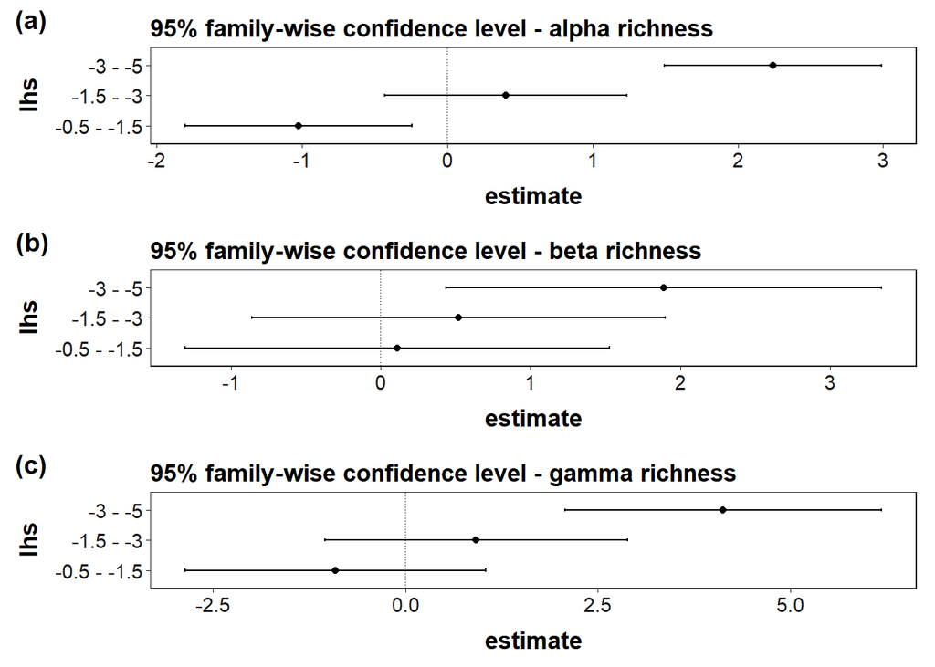

```r
Makroph_Lake_DepthS$TiefeFact <- as.factor(Makroph_Lake_DepthS$Tiefe)

# Alpha richness
aov1 = aov(ALPHA ~ (TiefeFact), data=Makroph_Lake_DepthS) #Fit an Analysis of Variance Model
Heteroaov1 <- glht(aov1,mcp(TiefeFact="Tukey") , vcov=vcovHC)
#summary(Heteroaov1)  #Studies sites do not significantly differ in ....
Herb1<-confint(Heteroaov1) %>%
  tidy %>%
  filter(lhs %in% c("-0.5 - -1.5","-1.5 - -3","-3 - -5"))%>% #to select just neighboring groups
  ggplot(aes(lhs, y=estimate, ymin=conf.low, ymax=conf.high)) +
    geom_hline(yintercept=0, linetype="11", colour="grey60") +
    geom_errorbar(width=0.1) +
    geom_point() +
    coord_flip()+
  ggtitle("95% family-wise confidence level - alpha richness")

#beta richness
aov2 = aov(BETA ~ (TiefeFact), data=Makroph_Lake_DepthS) #Fit an Analysis of Variance Model
Heteroaov2 <- glht(aov2,mcp(TiefeFact="Tukey") , vcov=vcovHC)
#summary(Heteroaov2)  #Studies sites do not significantly differ in ....
Herb2<-confint(Heteroaov2) %>%
  tidy %>%
  filter(lhs %in% c("-0.5 - -1.5","-1.5 - -3","-3 - -5"))%>% #to select just neighboring groups
  ggplot(aes(lhs, y=estimate, ymin=conf.low, ymax=conf.high)) +
    geom_hline(yintercept=0, linetype="11", colour="grey60") +
    geom_errorbar(width=0.1) +
    geom_point() +
    coord_flip()+
  ggtitle("95% family-wise confidence level - beta richness")

#Gamma richness
aov3 = aov(GAMMA ~ (TiefeFact), data=Makroph_Lake_DepthS) #Fit an Analysis of Variance Model
Heteroaov3 <- glht(aov3,mcp(TiefeFact="Tukey") , vcov=vcovHC)
#summary(Heteroaov3)  #Studies sites do not significantly differ in ....
Herb3<-confint(Heteroaov3) %>%
  tidy %>%
  filter(lhs %in% c("-0.5 - -1.5","-1.5 - -3","-3 - -5"))%>% #to select just neighboring groups
  ggplot(aes(lhs, y=estimate, ymin=conf.low, ymax=conf.high)) +
    geom_hline(yintercept=0, linetype="11", colour="grey60") +
    geom_errorbar(width=0.1) +
    geom_point() +
    coord_flip() +
  ggtitle("95% family-wise confidence level - gamma richness")

ggarrange(Herb1,Herb2,Herb3, nrow = 3,labels=c("(a)","(b)","(c)"))
```

Figure 3: Simultaneous tests for linear models with multiple comparisons of means using Tukey contrasts that are robust under non-normality, heteroscedasticity and variable sample size (Herberich et al. 2010) to check significant differences between depths within richness components. Results are plotted for alpha richness (a), beta richness (b) and gamma richness(c).

## 1.4 DDG pattern types

Table 1: Overview about DDG patterns of decreasing curves, hump-shaped curves (different peak depths) and increasing curves. Shows number of field campaigns (lake*year) showing a distinct depth pattern for each richness component.

```r
## Organize DDG into Depth patterns
#For Alpha Richness peak
PEAK$DepthGroup<-if_else(PEAK$AlphaPeakDepth>-1,
                         "Decreasing curve (Peak: >-1m)",
                                  if_else(PEAK$AlphaPeakDepth>-2,
                                          "Hump-shaped (Peak: -1- -2m)",
                                          if_else(PEAK$AlphaPeakDepth>-4,
                                                  "Hump-shaped (Peak: -2- -4m)",
                                                  "Increasing curve (Peak: <-4m)")))

PEAKCLASSAlpha<-PEAK %>% group_by(DepthGroup) %>%
  dplyr::summarise(Alpha_N=n_distinct(interaction(Lake,YEAR)))

#For Gamma Richness peak
PEAKCLASS2<-PEAK  %>% group_by(GammaPeakDepth) %>%
  dplyr::summarise(datasets=n_distinct(interaction(Lake,YEAR)))
PEAKCLASS2$DepthGroup<-if_else(PEAKCLASS2$GammaPeakDepth>-1,
                               "Decreasing curve (Peak: >-1m)",
                                  if_else(PEAKCLASS2$GammaPeakDepth>-2,
                                          "Hump-shaped (Peak: -1- -2m)",
                                  if_else(PEAKCLASS2$GammaPeakDepth>-4,
                                          "Hump-shaped (Peak: -2- -4m)",
                                          "Increasing curve (Peak: <-4m)")))
PEAKCLASSGamma<-PEAKCLASS2 %>% group_by(DepthGroup) %>% dplyr::summarise(Gamma_N=sum(datasets))

#For Beta Richness peak
PEAKCLASS3<-PEAK %>% group_by(BetaPeakDepth) %>%
  dplyr::summarise(datasets=n_distinct(interaction(Lake,YEAR)))
PEAKCLASS3$DepthGroup<-if_else(PEAKCLASS3$BetaPeakDepth>-1,
                               "Decreasing curve (Peak: >-1m)",
                               if_else(PEAKCLASS3$BetaPeakDepth>-2,
                                       "Hump-shaped (Peak: -1- -2m)",
                                  if_else(PEAKCLASS3$BetaPeakDepth>-4,
                                          "Hump-shaped (Peak: -2- -4m)",
                                          "Increasing curve (Peak: <-4m)")))
PEAKCLASSBeta<-PEAKCLASS3 %>% group_by(DepthGroup) %>% dplyr::summarise(Beta_N=sum(datasets))

#Combine results
PEAKCLASS<-transpose(left_join(left_join(PEAKCLASSAlpha,PEAKCLASSBeta,
                                         by="DepthGroup"),PEAKCLASSGamma,by="DepthGroup"),
          keep.names = "col", make.names = "DepthGroup")

rownames(PEAKCLASS) <- PEAKCLASS[,1]
PEAKCLASS[,1] <- NULL
PEAKCLASS
```

|  | Decreasing curve (Peak: >-1m) | Hump-shaped (Peak: -1- -2m) | Hump-shaped (Peak: -2- -4m) | Increasing curve (Peak: <-4m) |
| --- | --- | --- | --- | --- |
| Alpha_N | 6 | 41 | 52 | 1 |
| Beta_N | 40 | 31 | 22 | 7 |
| Gamma_N | 26 | 39 | 30 | 5 |

## 1.5 Correlations between richness components

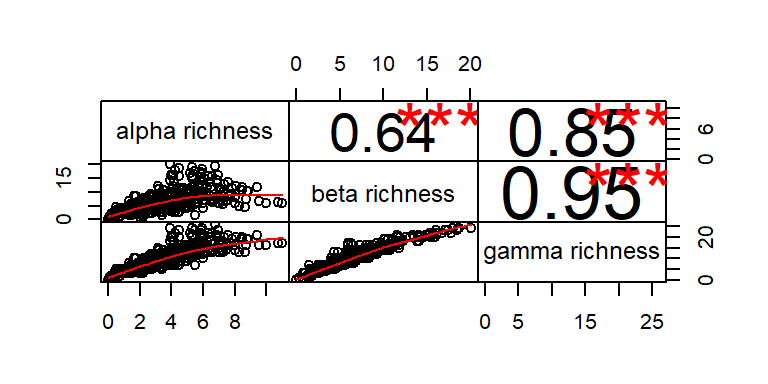

```r
richness<-Makroph_Lake_DepthS[c(97,101,99)]
colnames(richness) <- c("alpha richness", "beta richness", "gamma richness")
chart.Correlation(richness, histogram=F, pch=9, method = "pearson")
```

Figure 4: Correlations between diversity metrices (method = pearson). Significance levels of p-values: *p<0.1;**p<0.05;***p<0.01

## 1.6 Correlations between DDG metrices

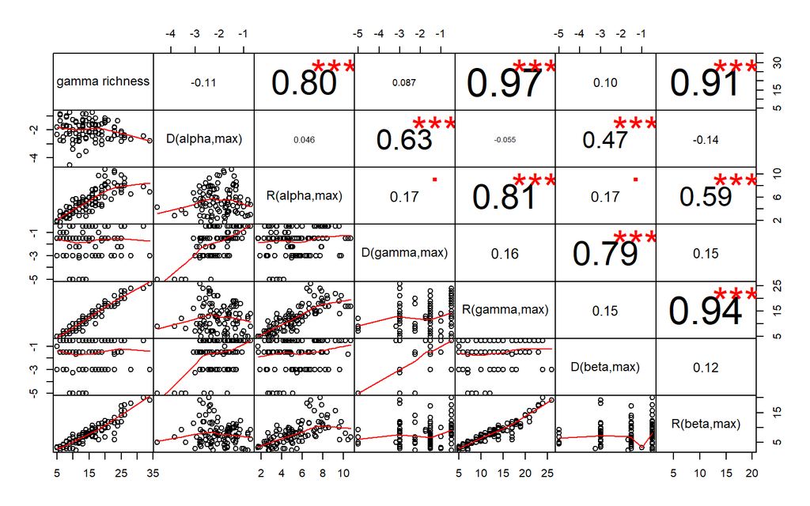

```r
peakvalues<-PEAK[c(18,3,5,14,15,16,17)]
colnames(peakvalues) <- c("gamma richness", "D(alpha,max)", "R(alpha,max)", "D(gamma,max)", "R(gamma,max)", "D(beta,max)", "R(beta,max)")
chart.Correlation(peakvalues, histogram=F, pch=9, method = "pearson")
```

Figure 5: Pearson correlations between DDG measures of different species richness components. Significance levels of p-values: *p<0.1;**p<0.05;***p<0.01

## 1.7 Chi-square test of DDG pattern

Chi-square is done to see siginificant differences in frequency among the DDG pattern types (Table 1) to see if they are significantly different for each richness component.

```r
#Chi-square test
chi<-chisq.test(PEAKCLASS, simulate.p.value=TRUE)
chi
```

```
##
##  Pearson's Chi-squared test with simulated p-value (based on 2000
##  replicates)
##
## data:  PEAKCLASS
## X-squared = 44.078, df = NA, p-value = 0.0004998
```

# 2 Depth diversity gradients of macrophytes: drivers

## 2.1 Data representativeness of nested subsets

To show that the diversity metrics of the environmental & biodiversity dataset are representative for the diversity metrics of biodiversity dataset we applied the PERMANOVA test adonis2, using the R package ‘vegan’ which compares centroids and the variance (Oksanen et al. 2019). A non-significant result (p>0.05) confirms that centroids and variance of two groups are not different. The results show that the Environmental & biodiversity dataset (N=27) is representative for the Biodiversity dataset (N=100).

```r
adonis2(PEAK[,c(3,5)]~datasettotsimpl, data=PEAK, by = NULL) #ALPHAPEAK
```

|  | Df | SumOfSqs | R2 | F | Pr(>F) |
| --- | --- | --- | --- | --- | --- |
| Model | 1 | 0.8705645 | 0.006633814 | 0.6544553 | 0.531 |
| Residual | 98 | 130.3608089 | 0.993366186 | NA | NA |
| Total | 99 | 131.2313734 | 1.000000000 | NA | NA |

```r
adonis2((PEAK[,c(14,15)])~datasettotsimpl, data=PEAK, by = NULL) #GammaPEAK
```

|  | Df | SumOfSqs | R2 | F | Pr(>F) |
| --- | --- | --- | --- | --- | --- |
| Model | 1 | 0.169023 | 0.02018484 | 2.018865 | 0.128 |
| Residual | 98 | 8.204736 | 0.97981516 | NA | NA |
| Total | 99 | 8.373759 | 1.00000000 | NA | NA |

```r
adonis2(scale(PEAK[,c(16,17)])~datasettotsimpl, data=PEAK, by = NULL) #BetaPEAK
```

|  | Df | SumOfSqs | R2 | F | Pr(>F) |
| --- | --- | --- | --- | --- | --- |
| Model | 1 | -45388.37 | -0.2618225 | -20.33456 | 0.646 |
| Residual | 98 | 218743.84 | 1.2618225 | NA | NA |
| Total | 99 | 173355.47 | 1.0000000 | NA | NA |

## 2.2 Correlations between drivers

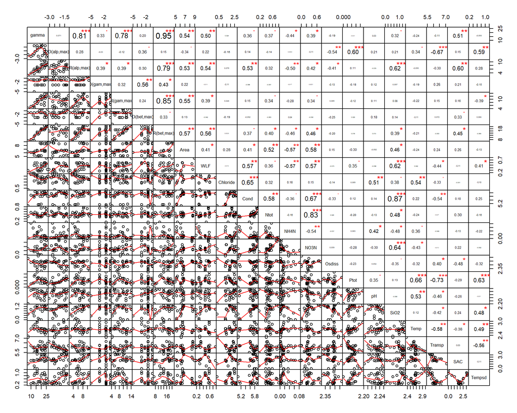

```r
PEAK_Chem_norm_BA<-PEAK_Chem_norm %>% filter(WLF!="NA") %>% filter(SAC!="NA")

values<-PEAK_Chem_norm_BA[c(33,20,22,31,32,29,30,16,19,3:15)]
colnames(values) <- c("gamma", "D(alp,max)", "R(alp,max)", "D(gam,max)", "R(gam,max)", "D(bet,max)", "R(bet,max)", "Area","WLF","Chloride","Cond","Ntot","NH4N", "NO3N","Osdiss","Ptot","pH","SiO2","Temp","Transp","SAC","Tempsd")


chart.Correlation(values,
                  histogram=F, pch=8, method = "pearson")
```

Figure 6: Pearson correlation between normalized chemical-physical values & DDG measures for all richness components. Environmental & biodiversity dataset is used. Significance levels of p-values: *p<0.1;**p<0.05;***p<0.01

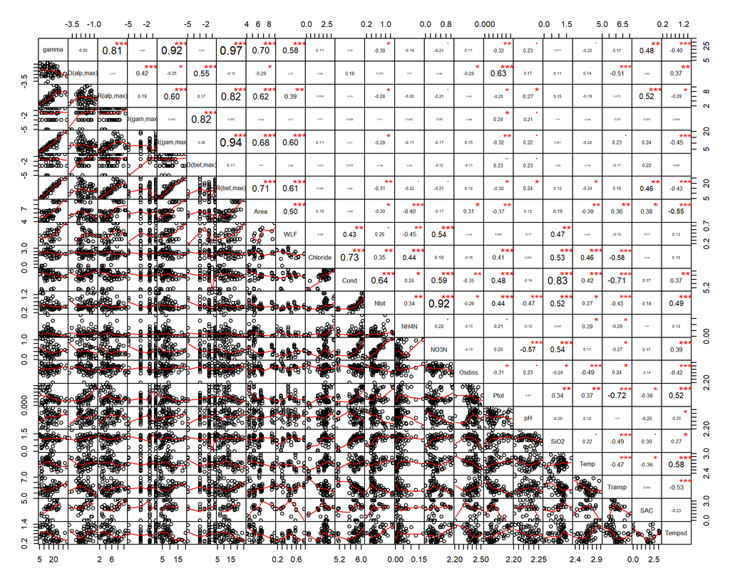

```r
values<-PEAK_Chem_norm[c(33,20,22,31,32,29,30,16,19,3:15)]
colnames(values) <- c("gamma", "D(alp,max)", "R(alp,max)", "D(gam,max)", "R(gam,max)", "D(bet,max)", "R(bet,max)", "Area","WLF","Chloride","Cond","Ntot","NH4N", "NO3N","Osdiss","Ptot","pH","SiO2","Temp","Transp","SAC","Tempsd")

chart.Correlation(values,
                  histogram=F, pch=9, method = "pearson")
```

Figure 7: Pearson correlation between normalized chemical-physical values & DDG measures for all richness components. Biodiversity dataset is used, zero values are ignored. Significance levels of p-values: *p<0.1;**p<0.05;***p<0.01

## 2.3 Principle component analysis

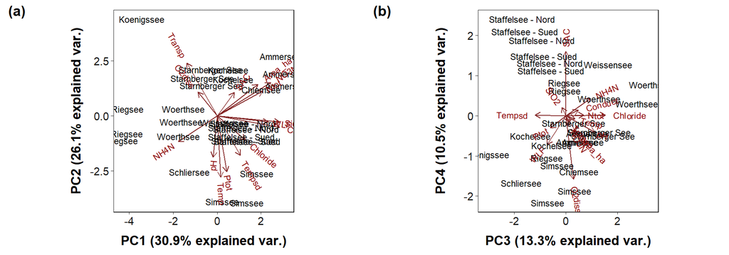

```r
#environmental & biodiversity dataset
label_lake<- PEAK_Chem_norm[complete.cases(PEAK_Chem_norm[,c(3:16,19)]),]
lak.pca <- prcomp(na.omit(label_lake[,c(3:16,19)]),center = TRUE, scale. = TRUE)
#print(lak.pca)
#summary(lak.pca)
PCA <- (data.frame(label_lake$Lake))
PCA$YEAR <- label_lake$YEAR
PCA$PC1 <- lak.pca$x[,1]
PCA$PC2 <- lak.pca$x[,2]
PCA$PC3 <- lak.pca$x[,3]
PCA$PC4 <- lak.pca$x[,4]

names(PCA)[1]<-"Lake"

PEAK_PCA<-merge(PCA, PEAK_Chem_norm, by=c("Lake", "YEAR"))

#Plot
library(ggbiplot)
p1<- ggbiplot(lak.pca, choices = 1:2, obs.scale = 1, var.scale = 1,
              labels=label_lake$Lake, arrow.color = "#FF0000",
              ellipse = TRUE, cicle = TRUE)
p2<- ggbiplot(lak.pca, choices = 3:4, obs.scale = 1, var.scale = 1,
              labels=label_lake$Lake, arrow.color = "#FF0000",
              ellipse = TRUE, cicle = TRUE)
figure <- ggarrange(p1,p2,
                    labels = c("(a)","(b)"),
                    ncol = 2, nrow = 1, common.legend = TRUE, legend = "bottom", align = "hv")
figure
```

## 2.4 GAMM for gamma richness & beta and gamma DDG measures

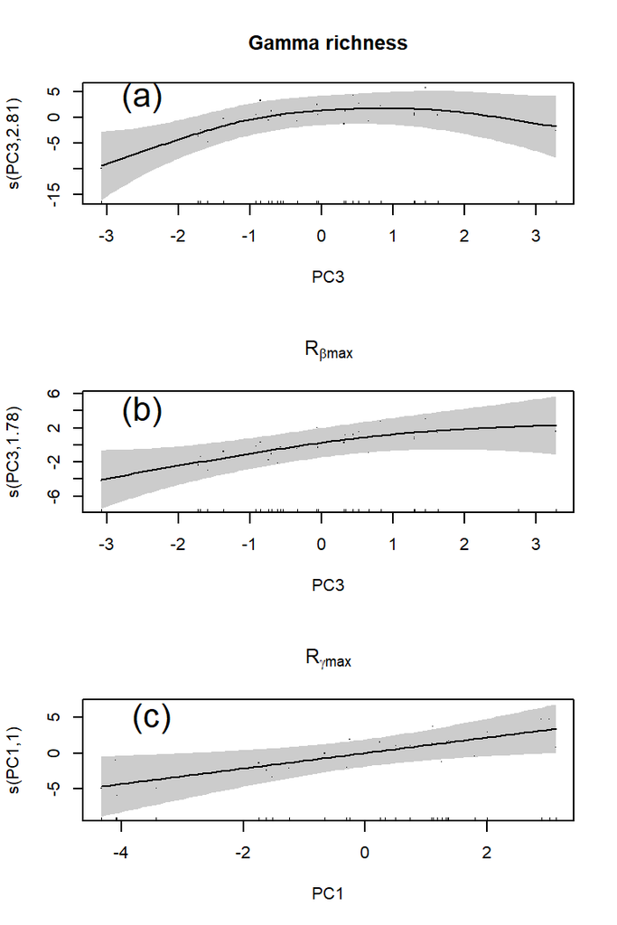

```r
#Beta
# gam_BetaPeakDepth <- gamm4(BetaPeakDepth ~ s(PC1)+s(PC2)+s(PC3)+s(PC4),
#                             random= ~(1|Lake), # package gamm4
#                             data=PEAK_PCA)
# summary(gam_BetaPeakDepth$gam)


gam_BetaPeakRichness <- gamm4(BetaPeakRichness ~ s(PC3),
                               random= ~(1|Lake), # package gamm4
                               data=PEAK_PCA)
#summary(gam_BetaPeakRichness$gam)

#Gamma
# gam_GammaPeakDepth <- gamm4(GammaPeakDepth ~ s(PC1)+s(PC2)+s(PC3)+s(PC4),
#                             random= ~(1|Lake), # package gamm4
#                             data=PEAK_PCA)
# summary(gam_GammaPeakDepth$gam)


gam_GammaPeakRichness <- gamm4(GammaPeakRichness ~ s(PC1),
                               random= ~(1|Lake), # package gamm4
                               data=PEAK_PCA)
#summary(gam_GammaPeakRichness$gam)

# Gamma richness
gam_Gamma <- gamm4(GAMMA ~ s(PC3), #s(PC1)+s(PC2)+s(PC3)+s(PC4)
                            random= ~(1|Lake), # package gamm4
                            data=PEAK_PCA)
#summary(gam_Gamma$gam)



#Plot
par(mfrow=c(3,1))
plot(gam_Gamma$gam, residuals=TRUE, main = "Gamma richness",shade = T,seWithMean=T)
text(-2.5, 4.0, "(a)", cex=2)
plot(gam_BetaPeakRichness$gam,residuals=TRUE, main = expression(R[beta][max]),
     shade = T,seWithMean=T)
text(-2.5, 4.0, "(b)", cex=2)
plot(gam_GammaPeakRichness$gam,residuals=TRUE, main = expression(R[gamma][max]),
     shade = T,seWithMean=T)
text(-3.5, 5.0, "(c)", cex=2)
```

Figure 9: Minimal GAMMs for response variables Gamma richness (a), R(beta,max) (b) and R(gamma, max) (c). Low r_square (adj) were found: 0.213 (a); 0.0124 (b); 0.265 (c).

# 3 Depth diversity gradients of macrophytes: recent shifts

## 3.1 Invariability analysis

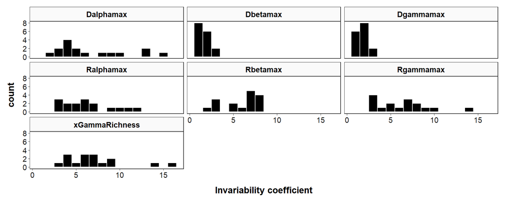

```r
LAKECHANGEInv<-PEAK %>%
  dplyr::group_by(Lake) %>% #summarize informtion for lakes (over timeseries)
  dplyr::summarise(NYEAR=n_distinct(YEAR),
             Dalphamax=mean(-AlphaPeakDepth)/sd(-AlphaPeakDepth),
             Ralphamax=mean(AlphaPeakRichness)/sd(AlphaPeakRichness),
             Dbetamax=mean(-BetaPeakDepth)/sd(-BetaPeakDepth),
             Rbetamax=mean(BetaPeakRichness)/sd(BetaPeakRichness),
             Dgammamax=mean(-GammaPeakDepth)/sd(-GammaPeakDepth),
             Rgammamax=mean(GammaPeakRichness)/sd(GammaPeakRichness),
             xGammaRichness=mean(GAMMA)/sd(GAMMA)
             )%>%
  filter(NYEAR>3) %>% #For timeseries dataset
  arrange(Dalphamax) %>%
  filter_all(all_vars(!is.infinite(.)))

#Plot
ggplot(LAKECHANGEInv %>% gather(Type, "Inv", 3:9)) +
  geom_histogram(aes(x=Inv), col="white", fill="black",binwidth = 1)+
  facet_wrap(~Type, ncol = 3)+
  xlab("Invariability coefficient")
```

Figure 10: Histograms for Invariability coefficients for single DDG measures (Dmax and Rmax of alpha, beta and gamma richness) and gamma richness for the biodiversity timeseries dataset. High invariability means a high stability within the timeseries.

## 3.2 Temporal trend of gamma richness

### 3.2.1 General

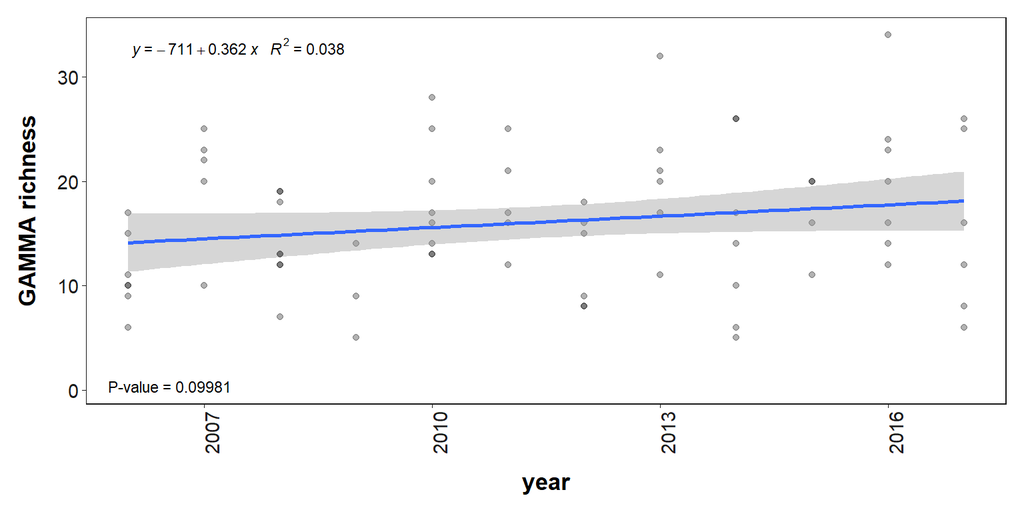

```r
library(ggpmisc)
library(lubridate)

BTD <- PEAK %>% group_by(Lake) %>% filter(n_distinct(YEAR)>3) %>%
    mutate(YEAR = as.numeric(as.character(YEAR)))

formula <- y ~ x

ggplot(data=BTD,
       aes(x=YEAR, y=GAMMA, label=sprintf("%0.2f", round(YEAR, digits = 0)))) +
  xlab("year")+ylab("GAMMA richness")+
  theme(axis.text.x = element_text(angle = 90, hjust = 1))+
  geom_point(alpha = 0.3) +
  geom_smooth(method = "lm", se = T) +
  stat_poly_eq(aes(label = paste(..eq.label.., ..rr.label.., sep = "~~~")),
               #label.x.npc = "left", label.y.npc = 0.15,
               formula = formula, parse = TRUE, size = 3)+
  stat_fit_glance(method = 'lm',
                  method.args = list(formula = formula),
                  geom = 'text',
                  aes(label = paste("P-value = ", signif(..p.value.., digits = 4), sep = "")),
                  label.x = 'left', label.y = 0.35, size = 3)+
    scale_x_continuous(breaks=c(2007,2010,2013,2016))
```

Figure 11: Temporal change of gamma richness from biodiversity time series dataset for all lakes together. Points show individual values and the blue line is a linear model.

### 3.2.2 Individual lakes

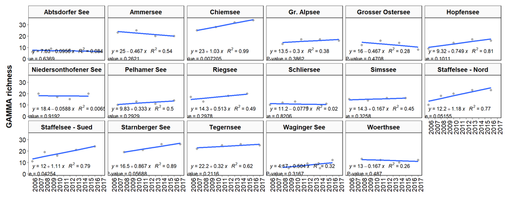

```r
library(ggpmisc)
formula <- y ~ x
ggplot(BTD, aes(x=factor(YEAR), y=GAMMA, group=factor(Lake))) +
  xlab("")+ylab("GAMMA richness")+theme(axis.text.x = element_text(angle = 90, hjust = 1))+
  geom_point(alpha = 0.3) +facet_wrap(vars(Lake),nrow=3) +
  geom_smooth(method = "lm", se = F, formula = y~x) +
  stat_poly_eq(aes(label = paste(..eq.label.., ..rr.label.., sep = "~~~")),
               label.x.npc = "left", label.y.npc = 0.15,
               formula = formula, parse = TRUE, size = 3)+
  stat_fit_glance(method = 'lm',
                  method.args = list(formula = formula),
                  geom = 'text',
                  aes(label = paste("P-value = ", signif(..p.value.., digits = 4), sep = "")),
                  label.x = 'left', label.y = 0.35, size = 3)
```

Figure 12: Temporal change of gamma richness from biodiversity time series dataset for all individual lakes. Points show single values and the blue line is a linear model per lake.

## 3.3 Temporal trend of DDG measures

### 3.3.1 General

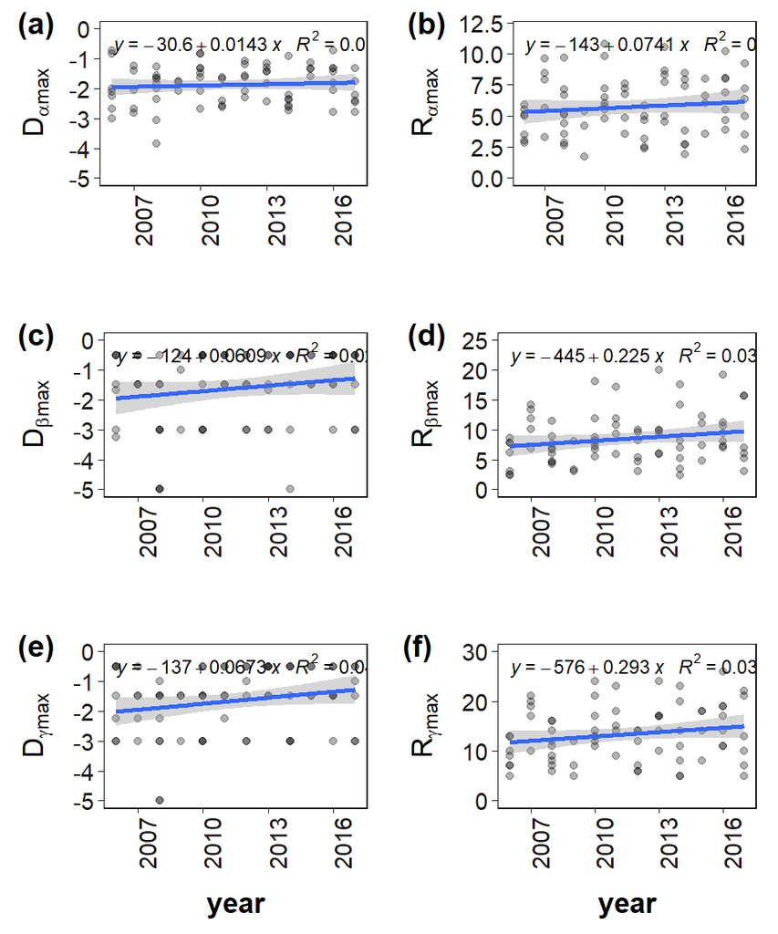

```r
library(ggpmisc)
formula <- y ~ x
A1<-ggplot(BTD,
           aes(x=YEAR, y=AlphaPeakDepth)) +
  xlab("")+ylab(expression(D[alpha][max]))+ ylim(-5,0)+
  theme(axis.text.x = element_text(angle = 90, hjust = 1))+
  geom_point(alpha = 0.3) +
  geom_smooth(method = "lm", se = T) +
  stat_poly_eq(aes(label = paste(..eq.label.., ..rr.label.., sep = "~~~")),
               #label.x = "left", label.y = -0.15,
               formula = formula, parse = TRUE, size = 3)+
  stat_fit_glance(method = 'lm',
                  method.args = list(formula = formula),
                  geom = 'text',
                  aes(label = paste("P-value = ", signif(..p.value.., digits = 3), sep = "")),
                  label.x = 6.0, label.y = -4.5, size = 3)+
    scale_x_continuous(breaks=c(2007,2010,2013,2016), limits = c(2006,2017))

A2<-ggplot(BTD,
           aes(x=YEAR, y=AlphaPeakRichness)) +
  xlab("")+ylab(expression(R[alpha][max]))+ylim(0,12)+
  theme(axis.text.x = element_text(angle = 90, hjust = 1))+
  geom_point(alpha = 0.3) +
  geom_smooth(method = "lm", se = T) +
  stat_poly_eq(aes(label = paste(..eq.label.., ..rr.label.., sep = "~~~")),
               #label.x = "left", label.y = 0.15,
               formula = formula, parse = TRUE, size = 3)+
  stat_fit_glance(method = 'lm',
                  method.args = list(formula = formula),
                  geom = 'text',
                  aes(label = paste("P-value = ", signif(..p.value.., digits = 3), sep = "")),
                  label.x = 6.0, label.y = 2, size = 3)+
    scale_x_continuous(breaks=c(2007,2010,2013,2016), limits = c(2006,2017))
B1<-ggplot(BTD,
           aes(x=YEAR, y=BetaPeakDepth)) +
  xlab("")+ylab(expression(D[beta][max]))+ylim(-5,0)+
  theme(axis.text.x = element_text(angle = 90, hjust = 1))+
  geom_point(alpha = 0.3) +
  geom_smooth(method = "lm", se = T) +
  stat_poly_eq(aes(label = paste(..eq.label.., ..rr.label.., sep = "~~~")),
               #label.x = "left", label.y = 0.15,
               formula = formula, parse = TRUE, size = 3)+
  stat_fit_glance(method = 'lm',
                  method.args = list(formula = formula),
                  geom = 'text',
                  aes(label = paste("P-value = ", signif(..p.value.., digits = 3), sep = "")),
                  label.x = 6.0, label.y = -4.5, size = 3)+
    scale_x_continuous(breaks=c(2007,2010,2013,2016), limits = c(2006,2017))
B2<-ggplot(BTD,
           aes(x=YEAR, y=BetaPeakRichness)) +
  xlab("")+ylab(expression(R[beta][max]))+ylim(0,25)+
  theme(axis.text.x = element_text(angle = 90, hjust = 1))+
  geom_point(alpha = 0.3) +
  geom_smooth(method = "lm", se = T) +
  stat_poly_eq(aes(label = paste(..eq.label.., ..rr.label.., sep = "~~~")),
              # label.x = "left", label.y = 0.15,
               formula = formula, parse = TRUE, size = 3)+
  stat_fit_glance(method = 'lm',
                  method.args = list(formula = formula),
                  geom = 'text',
                  aes(label = paste("P-value = ", signif(..p.value.., digits = 3), sep = "")),
                  label.x = 6.0, label.y = 2, size = 3)+
    scale_x_continuous(breaks=c(2007,2010,2013,2016), limits = c(2006,2017))
C1<-ggplot(BTD,
           aes(x=YEAR, y=GammaPeakDepth)) +
  xlab("year")+ylab(expression(D[gamma][max]))+ylim(-5,0)+
  theme(axis.text.x = element_text(angle = 90, hjust = 1))+
  geom_point(alpha = 0.3) +
  geom_smooth(method = "lm", se = T) +
  stat_poly_eq(aes(label = paste(..eq.label.., ..rr.label.., sep = "~~~")),
               #label.x = "left", label.y = 0.15,
               formula = formula, parse = TRUE, size = 3)+
  stat_fit_glance(method = 'lm',
                  method.args = list(formula = formula),
                  geom = 'text',
                  aes(label = paste("P-value = ", signif(..p.value.., digits = 3), sep = "")),
                  label.x = 6.0, label.y = -4.5, size = 3)+
    scale_x_continuous(breaks=c(2007,2010,2013,2016), limits = c(2006,2017))
C2<-ggplot(BTD,
           aes(x=YEAR, y=GammaPeakRichness)) +
  xlab("year")+ylab(expression(R[gamma][max]))+
  theme(axis.text.x = element_text(angle = 90, hjust = 1))+
  geom_point(alpha = 0.3) + ylim(0,30)+
  geom_smooth(method = "lm", se = T) +
  stat_poly_eq(aes(label = paste(..eq.label.., ..rr.label.., sep = "~~~")),
               #label.x = "left", label.y = 0.1,
               formula = formula, parse = TRUE, size = 3)+
  stat_fit_glance(method = 'lm',
                  method.args = list(formula = formula),
                  geom = 'text',
                  aes(label = paste("P-value = ", signif(..p.value.., digits = 3), sep = "")),
                  label.x = 6.0, label.y = 2,
                  size = 3)+
    scale_x_continuous(breaks=c(2007,2010,2013,2016), limits = c(2006,2017))

ggarrange(A1,A2,B1,B2,C1,C2, ncol=2, nrow = 3,labels=c("(a)","(b)","(c)","(d)","(e)","(f)"))
```

Figure 13: Temporal change of DDG metrices from biodiversity time series dataset for all lakes at once. Points show single values and the blue line is a linear model. In panel (a,c,e) temporal change of D(max) is shown and in panel (b,d,f) the corresponding course of R(max) is depicted.

### 3.3.2 Individual lakes

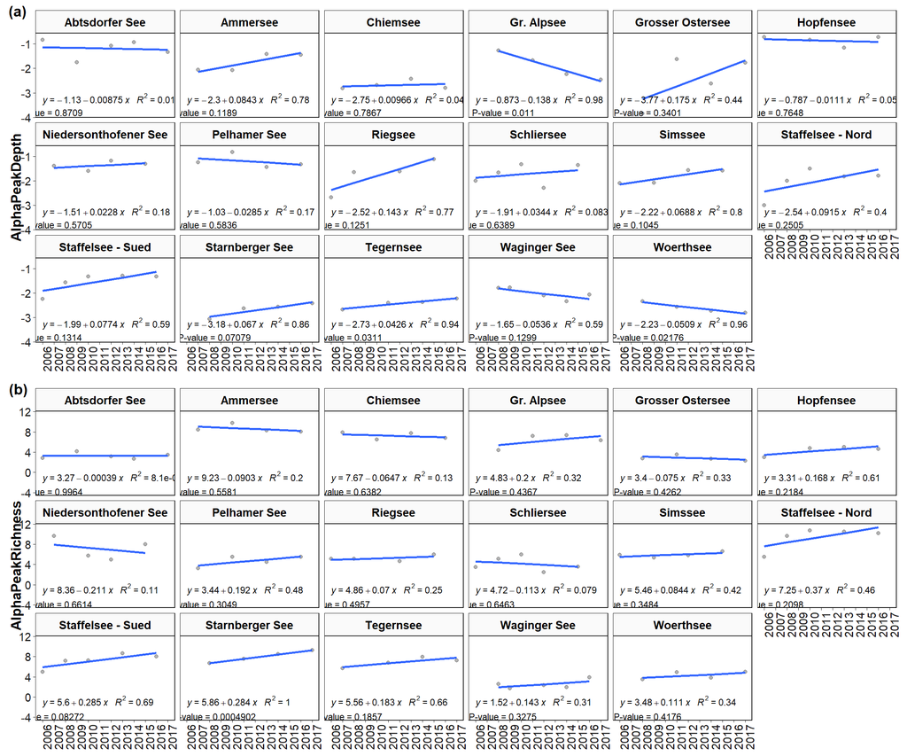

```r
library(ggpmisc)
formula <- y ~ x
T1<-ggplot(PEAK%>%group_by(Lake)%>%filter(n_distinct(YEAR)>3), aes(x=factor(YEAR), y=AlphaPeakDepth, group=factor(Lake)))+
  xlab("")+ylab("AlphaPeakDepth")+
  theme(axis.text.x = element_text(angle = 90, hjust = 1))+
  geom_point(alpha = 0.3) +facet_wrap(vars(Lake),nrow=3) +
  geom_smooth(method = "lm", se = F) +
  stat_poly_eq(aes(label = paste(..eq.label.., ..rr.label.., sep = "~~~")),
               label.x.npc = "left", label.y.npc = 0.15,
               formula = formula, parse = TRUE, size = 3)+
  stat_fit_glance(method = 'lm',
                  method.args = list(formula = formula),
                  geom = 'text',
                  aes(label = paste("P-value = ", signif(..p.value.., digits = 4), sep = "")),
                  label.x = 'left', label.y = -3.8, size = 3)



T2<-ggplot(PEAK%>%group_by(Lake)%>%filter(n_distinct(YEAR)>3), aes(x=factor(YEAR), y=AlphaPeakRichness, group=factor(Lake)))+
  xlab("")+ylab("AlphaPeakRichness")+
  theme(axis.text.x = element_text(angle = 90, hjust = 1))+
  geom_point(alpha = 0.3) +facet_wrap(vars(Lake),nrow=3) +
  geom_smooth(method = "lm", se = F) +
  stat_poly_eq(aes(label = paste(..eq.label.., ..rr.label.., sep = "~~~")),
               label.x.npc = "left", label.y.npc = 0.15,
               formula = formula, parse = TRUE, size = 3)+
  stat_fit_glance(method = 'lm',
                  method.args = list(formula = formula),
                  geom = 'text',
                  aes(label = paste("P-value = ", signif(..p.value.., digits = 4), sep = "")),
                  label.x = 'left', label.y = -3.8, size = 3)

ggarrange(T1,T2, nrow=2, labels = c("(a)","(b)"))
```

Figure 14: Temporal change of DDG metrices from biodiversity time series dataset for all lakes. Points show annual values and the blue line is a linear model. In panel (a) temporal change of D(alpha,max) is shown for all lakes and in panel (b) the corresponding course of R(alpha,max) is depicted.

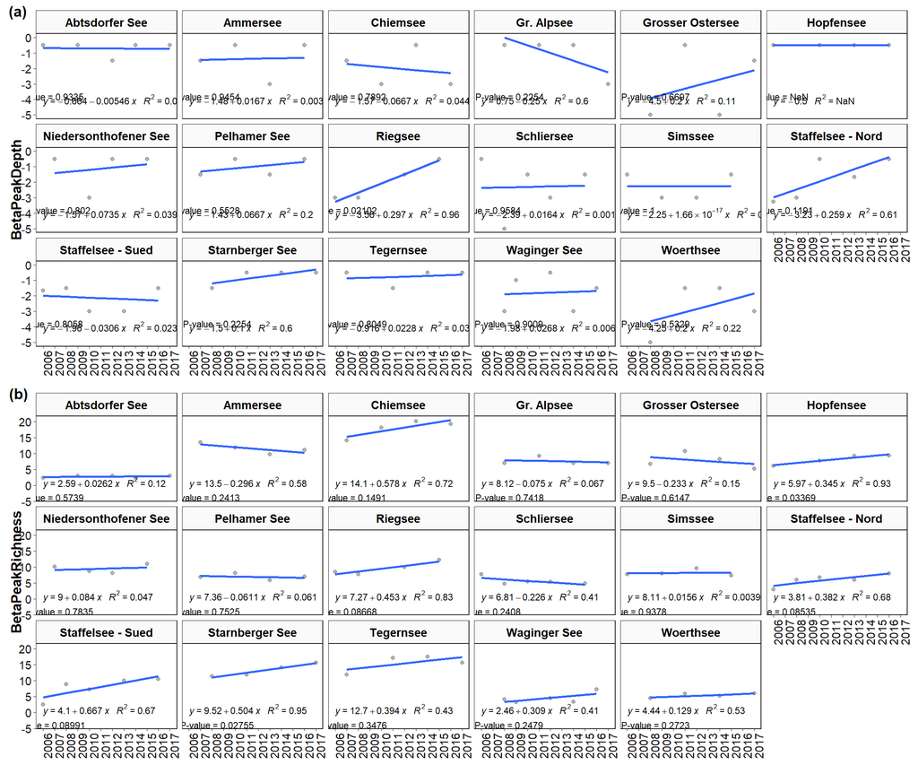

```r
formula <- y ~ x
T3<-ggplot(PEAK%>%group_by(Lake)%>%filter(n_distinct(YEAR)>3), aes(x=factor(YEAR), y=BetaPeakDepth, group=factor(Lake)))+
  xlab("")+ylab("BetaPeakDepth")+
  theme(axis.text.x = element_text(angle = 90, hjust = 1))+
  geom_point(alpha = 0.3) +facet_wrap(vars(Lake),nrow=3) +
  geom_smooth(method = "lm", se = F) +
  stat_poly_eq(aes(label = paste(..eq.label.., ..rr.label.., sep = "~~~")),
               label.x.npc = "left", label.y.npc = 0.15,
               formula = formula, parse = TRUE, size = 3)+
  stat_fit_glance(method = 'lm',
                  method.args = list(formula = formula),
                  geom = 'text',
                  aes(label = paste("P-value = ", signif(..p.value.., digits = 4), sep = "")),
                  label.x = 'left', label.y = -3.8, size = 3)

T4<-ggplot(PEAK%>%group_by(Lake)%>%filter(n_distinct(YEAR)>3), aes(x=factor(YEAR), y=BetaPeakRichness, group=factor(Lake)))+
  xlab("")+ylab("BetaPeakRichness")+
  theme(axis.text.x = element_text(angle = 90, hjust = 1))+
  geom_point(alpha = 0.3) +facet_wrap(vars(Lake),nrow=3) +
  geom_smooth(method = "lm", se = F) +
  stat_poly_eq(aes(label = paste(..eq.label.., ..rr.label.., sep = "~~~")),
               label.x.npc = "left", label.y.npc = 0.15,
               formula = formula, parse = TRUE, size = 3)+
  stat_fit_glance(method = 'lm',
                  method.args = list(formula = formula),
                  geom = 'text',
                  aes(label = paste("P-value = ", signif(..p.value.., digits = 4), sep = "")),
                  label.x = 'left', label.y = -3.8, size = 3)

ggarrange(T3,T4, nrow=2, labels = c("(a)","(b)"))
```

Figure 15: Temporal change of DDG metrices from biodiversity time series dataset for all lakes. Points show annual values and the blue line is a linear model. In panel (a) temporal change of D(beta,max) is shown for all lakes and in panel (b) the corresponding course of R(beta,max) is depicted.

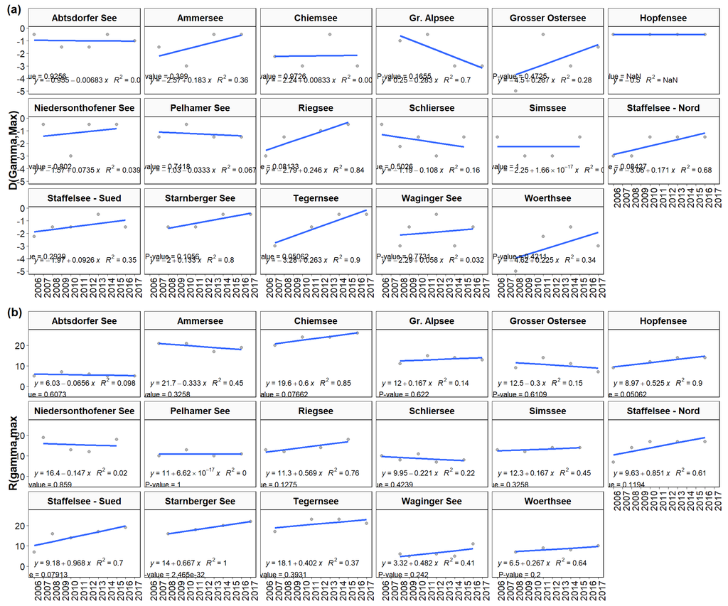

```r
formula <- y ~ x
T5<-ggplot(PEAK%>%group_by(Lake)%>%filter(n_distinct(YEAR)>3), aes(x=factor(YEAR), y=GammaPeakDepth, group=factor(Lake)))+
  xlab("")+ylab("D(Gamma,Max)")+
  theme(axis.text.x = element_text(angle = 90, hjust = 1))+
  geom_point(alpha = 0.3) +facet_wrap(vars(Lake),nrow=3) +
  geom_smooth(method = "lm", se = F) +
  stat_poly_eq(aes(label = paste(..eq.label.., ..rr.label.., sep = "~~~")),
               label.x.npc = "left", label.y.npc = 0.15,
               formula = formula, parse = TRUE, size = 3)+
  stat_fit_glance(method = 'lm',
                  method.args = list(formula = formula),
                  geom = 'text',
                  aes(label = paste("P-value = ", signif(..p.value.., digits = 4), sep = "")),
                  label.x = 'left', label.y = -3.8, size = 3)

T6<-ggplot(PEAK%>%group_by(Lake)%>%filter(n_distinct(YEAR)>3), aes(x=factor(YEAR), y=GammaPeakRichness, group=factor(Lake)))+
  xlab("")+ylab("R(gamma,max")+
  theme(axis.text.x = element_text(angle = 90, hjust = 1))+
  geom_point(alpha = 0.3) +facet_wrap(vars(Lake),nrow=3) +
  geom_smooth(method = "lm", se = F) +
  stat_poly_eq(aes(label = paste(..eq.label.., ..rr.label.., sep = "~~~")),
               label.x.npc = "left", label.y.npc = 0.15,
               formula = formula, parse = TRUE, size = 3)+
  stat_fit_glance(method = 'lm',
                  method.args = list(formula = formula),
                  geom = 'text',
                  aes(label = paste("P-value = ", signif(..p.value.., digits = 4), sep = "")),
                  label.x = 'left', label.y = -3.8, size = 3)

ggarrange(T5,T6, nrow=2, labels = c("(a)","(b)"))
```

Figure 16: Temporal change of DDG metrices from biodiversity time series dataset for all lakes. Points show annual values and the blue line is a linear model. In panel (a) temporal change of D(gamma,max) is shown for all lakes and in panel (b) the corresponding course of R(gamma,max) is depicted.

# 4 Literature

Herberich, E. et al. 2010. A Robust Procedure for Comparing Multiple Means under Heteroscedasticity in Unbalanced Designs (F Rapallo, Ed.). - PLoS ONE 5: e9788.

# 5 Session info

```r
Sys.time()
```

```
## [1] "2020-12-21 20:05:29 CET"
```